# Data Visualization and Dimensional reduction

# 3. t-SNE Plot

tSNE (t-Distributed Stochastic Neighbor Embedding) is a non-linear method used to visually cluster similar cells by reducing complex high-dimensional gene expression data into 2 dimensions.It place similar cells close together, and dissimilar cells far apart on a 2D plot. Unlike PCA, which is linear and easier to interpret, tSNE preserves local structure (relationships between nearby points).But it’s stochastic — running it twice on the same data can give different plots unless a seed is set.

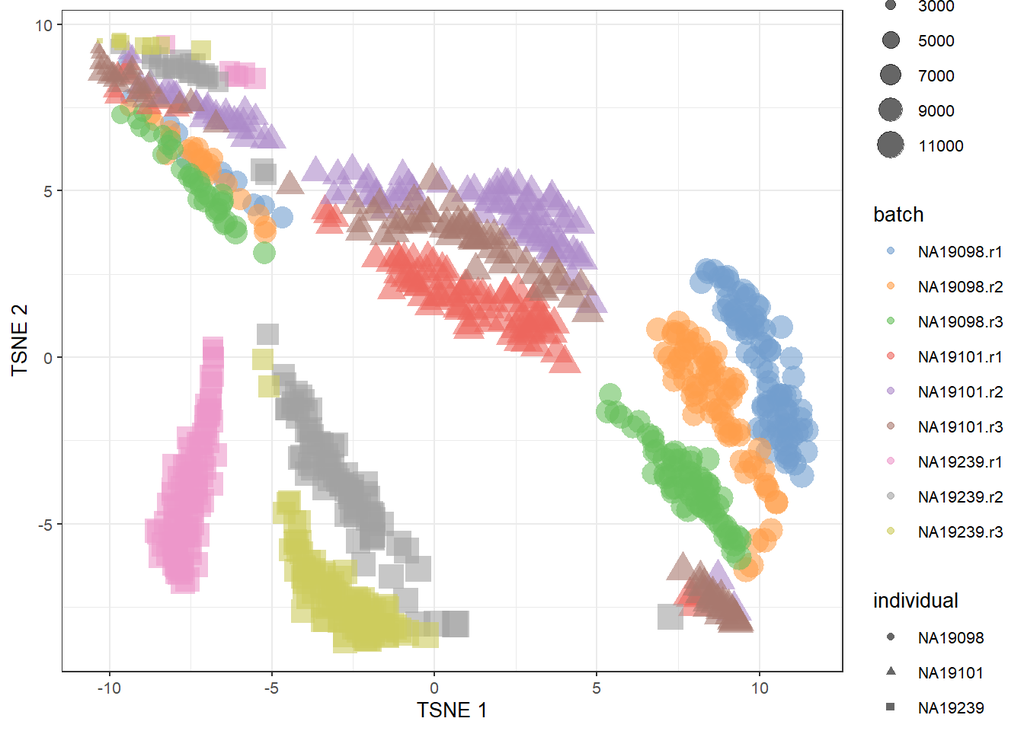

```r
#Before QC:

#Ensures reproducibility by fixing randomness.
set.seed(1234567)

#Run the tSNE algorithm using log-transformed raw counts. exprs_values = "logcounts_raw": Uses the log-transformed (but not normalized) expression matrix. perplexity = 130: Controls how many neighboring cells influence the tSNE layout. High = more connected structure, low = more separated clusters.
umi <- runTSNE(umi, exprs_values = "logcounts_raw", perplexity = 130)

#Plots the result, Color: Sequencing batch,size: Number of genes detected, shape: Biological individual.Before QC, tSNE may show batch-driven clusters or outliers, not true biology.

plotTSNE(umi, colour_by = "batch", size_by = "detected", shape_by = "individual")
```

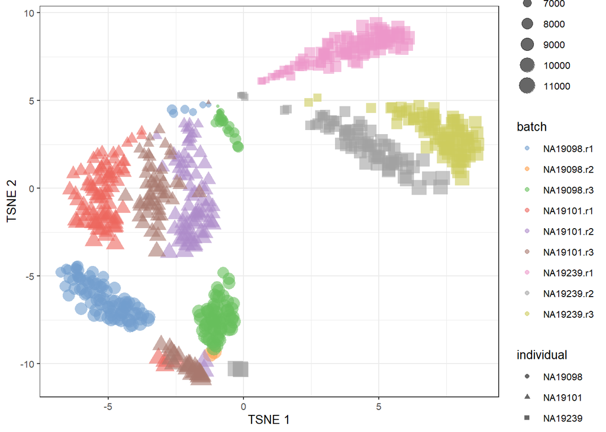

```r
#After QC

set.seed(1234567)

#Same steps, but using QC-filtered cells (umi.qc). Improved visualization: cells from problematic batches or replicates no longer appear as clear outliers (e.g., NA19098.r2 is fixed). You can now see better biological structure with less noise.
umi.qc <- runTSNE(umi.qc, exprs_values = "logcounts_raw", perplexity = 130)
plotTSNE(umi.qc, colour_by = "batch", size_by = "detected", shape_by = "individual")
```

#### Exercise 2 - Perplexity

Exercise 2 How do the tSNE plots change when a perplexity of 10 or 200 is used? How does the choice of perplexity affect the interpretation of the results?

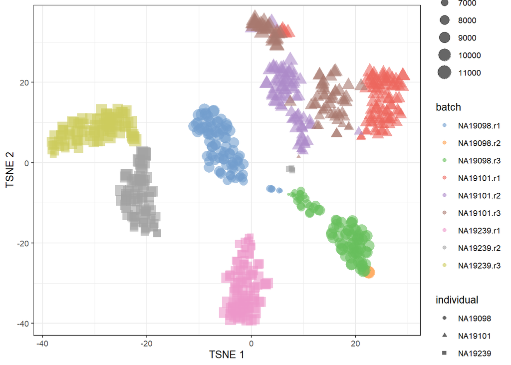

```r
#Perplexity of 10
umi.qc <- runTSNE(umi.qc, exprs_values = "logcounts_raw", perplexity = 10)
plotTSNE(umi.qc, colour_by = "batch", size_by = "detected", shape_by = "individual")
```

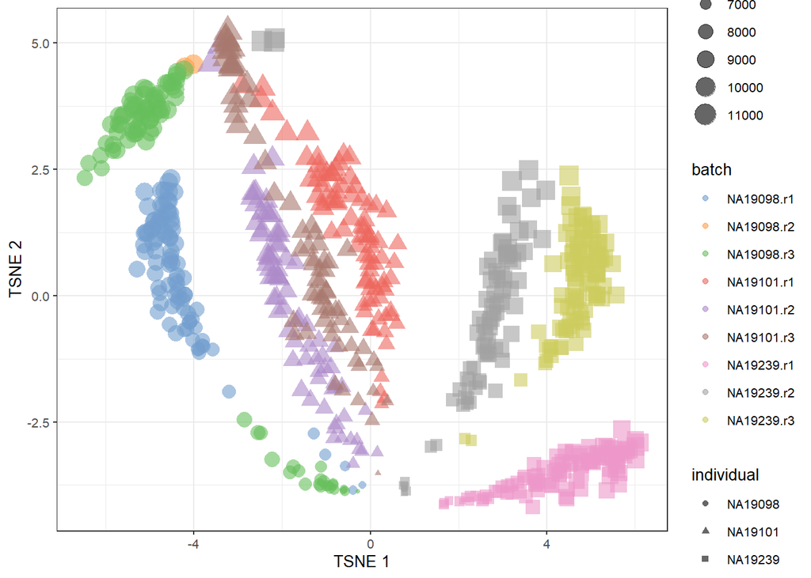

```r
#May show more scattered, tight clusters. Exaggerates small differences — useful for identifying rare cell types, but may split natural groups.

#Perplexity of 200
umi.qc <- runTSNE(umi.qc, exprs_values = "logcounts_raw", perplexity = 200)
plotTSNE(umi.qc, colour_by = "batch", size_by = "detected", shape_by = "individual")
```

```r
#Produces smoother plots with more blending. Merging distinct subgroups, hiding detail.
```